# EP03 Logistic Regression Practical 2

In this exercise we analyze the fracture data with logistic regression in R. This is a study concerning neurological deficit in thoracolumbar burst fractures. Between January 1981 and January 1991, 139 patients with thoracolumbar or lumbar burst fractures were treated in the Department of Orthopaedics and the Department of Neurosurgery of the Academic Hospital Dijkzigt of the Erasmus University of Rotterdam (Fontijne WPJ et al., J.of Bone & Joint Surgery, in press).

The following variables were observed:

- `ID`: Subject number
- `DEF`: the occurrence of neurological deficit (‘yes’ or ‘no’)
- `LOC`: the localization of the fracture (‘lumbar’, ‘thoracolumbar’ or ‘thoracic’)
- `STEN`: percentage spinal canal stenosis

### Question 1

Display a couple of records from the data set to see what it looks like. You could use the `head` function. Make a contingency table of the relation between the location of the fracture and the occurrence of neurological deficit. Is this relation statistically significant?

```r
head(fracture)
```

```
##   ID DEF           LOC STEN
## 1 45 yes      thoracic   10
## 2 72  no thoracolumbar   90
## 3 46 yes      thoracic   20
## 4 21 yes thoracolumbar    0
## 5  5 yes        lumbar    0
## 6  1 yes        lumbar    5
```

```r
(tab3a <- table(fracture$LOC, fracture$DEF,deparse.level = 2))
```

```
##                fracture$DEF
## fracture$LOC    no yes
##   lumbar        13   6
##   thoracolumbar 44  28
##   thoracic      33  15
```

```r
prop.table(tab3a, margin = 1)   # columnwise perc
```

```
##                fracture$DEF
## fracture$LOC           no       yes
##   lumbar        0.6842105 0.3157895
##   thoracolumbar 0.6111111 0.3888889
##   thoracic      0.6875000 0.3125000
```

```r
chisq.test(tab3a) # seems there is no relationship
```

```
##
##  Pearson's Chi-squared test
##
## data:  tab3a
## X-squared = 0.86635, df = 2, p-value = 0.6484
```

### Question 2

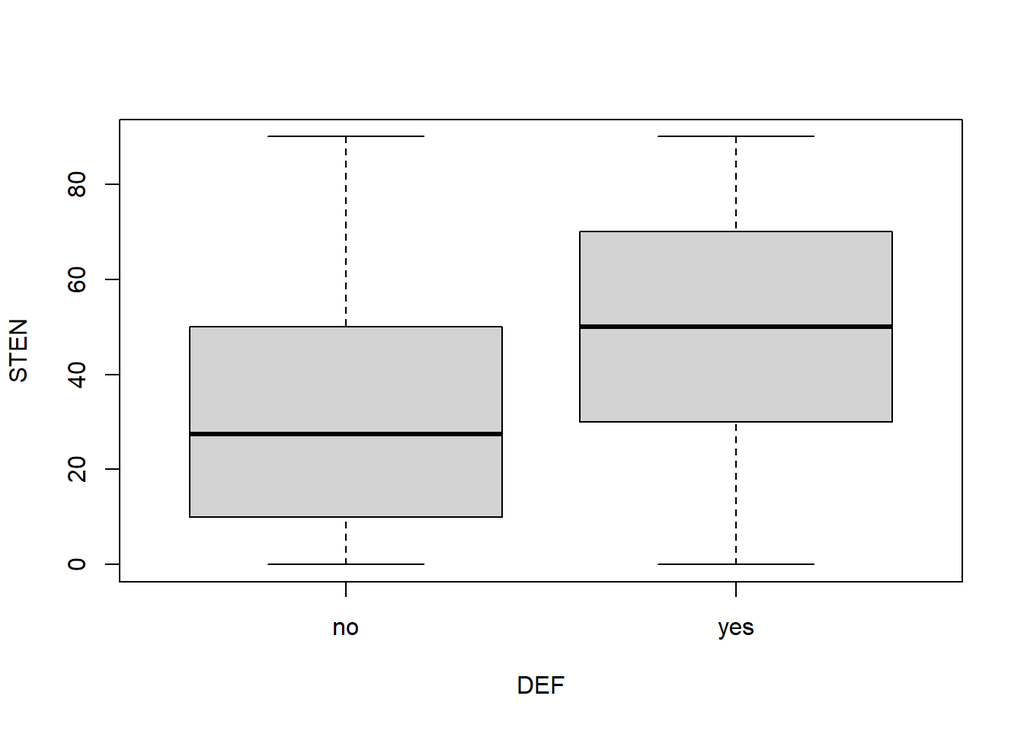

```r
# The code is:
boxplot(STEN~DEF, data=fracture)
```

```r
# Estimate the relationship using LOGISTIC regression
glm3b<-glm(DEF~STEN, family=binomial, data=fracture)
# Describe model by OR and CI
exp(coef(glm3b))
```

```
## (Intercept)        STEN
##   0.1894252   1.0272380
```

```r
exp(confint(glm3b))
```

```
##                  2.5 %    97.5 %
## (Intercept) 0.09079117 0.3680708
## STEN        1.01311593 1.0426793
```

```r
# Test using a LR test
drop1(glm3b, test = 'LRT')  # very significant
```

```
## Single term deletions
##
## Model:
## DEF ~ STEN
##        Df Deviance    AIC    LRT  Pr(>Chi)
## <none>      165.33 169.33
## STEN    1   180.42 182.42 15.093 0.0001023 ***
## ---
## Signif. codes:  0 '***' 0.001 '**' 0.01 '*' 0.05 '.' 0.1 ' ' 1
```

```r
# or do a t-test
t.test(STEN~ DEF, data=fracture, var.equal = FALSE)
```

```
##
##  Welch Two Sample t-test
##
## data:  STEN by DEF
## t = -3.9719, df = 93.782, p-value = 0.0001398
## alternative hypothesis: true difference in means is not equal to 0
## 95 percent confidence interval:
##  -27.408410  -9.138528
## sample estimates:
##  mean in group no mean in group yes
##          30.40000          48.67347
```

```r
# also very significant
```

### Question 3

Next look at the relationship between percentage stenosis and localization, describe and test it. How can you test which groups are significantly different?

```r
lm33<-lm(STEN~ LOC, data=fracture)
anova(lm33)
```

```
## Analysis of Variance Table
##
## Response: STEN
##            Df Sum Sq Mean Sq F value    Pr(>F)
## LOC         2  15423  7711.4   12.49 1.047e-05 ***
## Residuals 136  83966   617.4
## ---
## Signif. codes:  0 '***' 0.001 '**' 0.01 '*' 0.05 '.' 0.1 ' ' 1
```

```r
summary(lm33)
```

```
##
## Call:
## lm(formula = STEN ~ LOC, data = fracture)
##
## Residuals:
##     Min      1Q  Median      3Q     Max
## -48.729 -19.066   0.597  15.597  55.597
##
## Coefficients:
##                  Estimate Std. Error t value Pr(>|t|)
## (Intercept)        16.053      5.700   2.816  0.00559 **
## LOCthoracolumbar   18.350      6.409   2.863  0.00486 **
## LOCthoracic        32.677      6.735   4.852  3.3e-06 ***
## ---
## Signif. codes:  0 '***' 0.001 '**' 0.01 '*' 0.05 '.' 0.1 ' ' 1
##
## Residual standard error: 24.85 on 136 degrees of freedom
## Multiple R-squared:  0.1552, Adjusted R-squared:  0.1428
## F-statistic: 12.49 on 2 and 136 DF,  p-value: 1.047e-05
```

```r
# better apply a bonferroni correction !!!
```

### Question 4

Now we will use logistic regression to examine the effect of percentage stenosis and localization on the probability of neurological deficit simultaneously. Specify a model with the covariates LOC, STEN and the interaction between these two. Is it justified to fit a model without the interaction term?

```r
# The code is:
glm34 <-glm(DEF~LOC*STEN,data=fracture, family = binomial)
summary(glm34)
```

```
##
## Call:
## glm(formula = DEF ~ LOC * STEN, family = binomial, data = fracture)
##
## Deviance Residuals:
##     Min       1Q   Median       3Q      Max
## -1.9578  -0.8849  -0.5895   1.1084   2.1157
##
## Coefficients:
##                       Estimate Std. Error z value Pr(>|z|)
## (Intercept)           -1.08786    0.71228  -1.527    0.127
## LOCthoracolumbar      -0.87174    0.89904  -0.970    0.332
## LOCthoracic           -1.34636    1.08981  -1.235    0.217
## STEN                   0.01874    0.02936   0.638    0.523
## LOCthoracolumbar:STEN  0.02256    0.03193   0.706    0.480
## LOCthoracic:STEN       0.01214    0.03216   0.378    0.706
##
## (Dispersion parameter for binomial family taken to be 1)
##
##     Null deviance: 180.42  on 138  degrees of freedom
## Residual deviance: 159.24  on 133  degrees of freedom
## AIC: 171.24
##
## Number of Fisher Scoring iterations: 4
```

```r
exp(coef(glm34))
```

```
##           (Intercept)      LOCthoracolumbar           LOCthoracic
##             0.3369356             0.4182218             0.2601866
##                  STEN LOCthoracolumbar:STEN      LOCthoracic:STEN
##             1.0189187             1.0228146             1.0122174
```

```r
exp(confint(glm34))
```

```
##                            2.5 %   97.5 %
## (Intercept)           0.07114421 1.267405
## LOCthoracolumbar      0.07211899 2.632151
## LOCthoracic           0.02755986 2.169645
## STEN                  0.95850042 1.088598
## LOCthoracolumbar:STEN 0.95387383 1.092155
## LOCthoracic:STEN      0.94370580 1.081353
```

```r
# Lets see if we need interaction
drop1(glm34, test='LRT')
```

```
## Single term deletions
##
## Model:
## DEF ~ LOC * STEN
##          Df Deviance    AIC     LRT Pr(>Chi)
## <none>        159.24 171.24
## LOC:STEN  2   159.89 167.89 0.64997   0.7225
```

```r
# OR
glm340 <-glm(DEF~LOC+STEN,data=fracture, family = binomial)
anova(glm34, glm340, test='LRT')
```

```
## Analysis of Deviance Table
##
## Model 1: DEF ~ LOC * STEN
## Model 2: DEF ~ LOC + STEN
##   Resid. Df Resid. Dev Df Deviance Pr(>Chi)
## 1       133     159.24
## 2       135     159.89 -2 -0.64997   0.7225
```

### Question 5

Now fit a logistic model without the interaction term. Save the predicted probabilities. We will use this variable later. Looking at the results answer the following questions: - Does the percentage stenosis have a significant effect on neurological deficit, adjusted for localization? Describe the estimated effect. - Is localization significantly associated with the probability of neurological deficit (adjusted for percentage stenosis)? What is the p-value? - What are the odds ratios of the localization categories thoracic and thoracolumbar versus lumbar?

```r
glm35 <-glm(DEF~LOC+STEN,data=fracture, family = binomial)
summary(glm35)
```

```
##
## Call:
## glm(formula = DEF ~ LOC + STEN, family = binomial, data = fracture)
##
## Deviance Residuals:
##     Min       1Q   Median       3Q      Max
## -1.8167  -0.8804  -0.6205   1.0923   2.2009
##
## Coefficients:
##                   Estimate Std. Error z value Pr(>|z|)
## (Intercept)      -1.372884   0.534525  -2.568   0.0102 *
## LOCthoracolumbar -0.352669   0.601828  -0.586   0.5579
## LOCthoracic      -1.307604   0.710851  -1.839   0.0658 .
## STEN              0.035139   0.008664   4.056    5e-05 ***
## ---
## Signif. codes:  0 '***' 0.001 '**' 0.01 '*' 0.05 '.' 0.1 ' ' 1
##
## (Dispersion parameter for binomial family taken to be 1)
##
##     Null deviance: 180.42  on 138  degrees of freedom
## Residual deviance: 159.89  on 135  degrees of freedom
## AIC: 167.89
##
## Number of Fisher Scoring iterations: 4
```

```r
exp(coef(glm35))
```

```
##      (Intercept) LOCthoracolumbar      LOCthoracic             STEN
##        0.2533751        0.7028096        0.2704673        1.0357638
```

```r
exp(confint(glm35))
```

```
##                       2.5 %    97.5 %
## (Intercept)      0.08181291 0.6887296
## LOCthoracolumbar 0.21877130 2.3884479
## LOCthoracic      0.06525617 1.0930009
## STEN             1.01911358 1.0545436
```

```r
drop1(glm35, test='LRT')
```

```
## Single term deletions
##
## Model:
## DEF ~ LOC + STEN
##        Df Deviance    AIC     LRT  Pr(>Chi)
## <none>      159.89 167.89
## LOC     2   165.33 169.33  5.4375   0.06596 .
## STEN    1   179.55 185.55 19.6620 9.242e-06 ***
## ---
## Signif. codes:  0 '***' 0.001 '**' 0.01 '*' 0.05 '.' 0.1 ' ' 1
```

```r
# STENOSIS is significant
# Odds increase by 3% for each unit increase
# Location is not significant
# save predicted
preds <- predict(glm35,type = 'response')
```

### Question 6

Now fit the model again after changing the coding of the dummies for LOC such that thoracic is used as reference. In `glm` we can do this by including `c(LOC, base=3)` as a model term (3 because thoracic is the third level of this variable which you can check using the `levels` function). Before you run this model, try to find out what will be the estimates for the Constant and for the dummies. When you have run the new model, check whether the estimates are as expected.

```r
# When LOC(thoracic) will be the reference:
#  Constant: -1.373 - 1.307 = -2.680
# LOC(1) : lumbar/thracic = +1.307
# LOC(2) : thoracolumbar/thoracic = -0.353 - (-1.307) = 0.954
# Now take the exp
# The code is:
levels(fracture$LOC) # 3rd level is thoracic
```

```
## [1] "lumbar"        "thoracolumbar" "thoracic"
```

```r
glm36 <-glm(DEF~C(LOC, base=3)+STEN,data=fracture, family = binomial)
glm36
```

```
##
## Call:  glm(formula = DEF ~ C(LOC, base = 3) + STEN, family = binomial,
##     data = fracture)
##
## Coefficients:
##       (Intercept)  C(LOC, base = 3)1  C(LOC, base = 3)2               STEN
##          -2.68049            1.30760            0.95493            0.03514
##
## Degrees of Freedom: 138 Total (i.e. Null);  135 Residual
## Null Deviance:       180.4
## Residual Deviance: 159.9     AIC: 167.9
```

```r
exp(coef(glm36))
```

```
##       (Intercept) C(LOC, base = 3)1 C(LOC, base = 3)2              STEN
##        0.06852968        3.69730493        2.59850140        1.03576375
```

### Question 7

Next switch to the ‘Deviation coding’ contrast for LOC instead, by running the command: `contrasts(fracture$LOC) <- contr.sum(3)` In this case the effect of category 3 of LOC (the last category) is the negative sum of the effects of the categories 1 and 2. Fit the model using this coding and compare the estimated coefficients again.

```r
# The code is:
contrastsbase<- contrasts(fracture$LOC)
contrasts(fracture$LOC) <- contr.sum(3)
glm37 <-glm(DEF~C(LOC, base=3)+STEN,data=fracture, family = binomial)
glm37
```

```
##
## Call:  glm(formula = DEF ~ C(LOC, base = 3) + STEN, family = binomial,
##     data = fracture)
##
## Coefficients:
##       (Intercept)  C(LOC, base = 3)1  C(LOC, base = 3)2               STEN
##          -2.68049            1.30760            0.95493            0.03514
##
## Degrees of Freedom: 138 Total (i.e. Null);  135 Residual
## Null Deviance:       180.4
## Residual Deviance: 159.9     AIC: 167.9
```

```r
exp(coef(glm37))
```

```
##       (Intercept) C(LOC, base = 3)1 C(LOC, base = 3)2              STEN
##        0.06852968        3.69730493        2.59850140        1.03576375
```

```r
# restore contrast
contrasts(fracture$LOC)<-contrastsbase
```

### Question 8

What is the predicted probability of neurological deficit for a patient with a thoracic fracture and a stenosis of 60%? (Using the model from Ex 5.)

```r
# The code is:
preddata<-data.frame(LOC=factor('thoracic', levels = levels(fracture$LOC)), STEN=60)
predict(glm35, newdata = preddata, type='response' )
```

```
##         1
## 0.3607423
```

### Question 9

The functions cooks.distance and dfbetas gives you the Cook’s distances and the dfbetas of the observations. Use: `coo_1 <- cooks.distance(glm35)` And try to find the patients with large value for Cook’s distance. You may also sort the cases by the variable (in descending order) and print the cases with a high value. head(fracture[order(coo_1,decreasing = TRUE),], 10)

```r
# The code is:
diagnost3<- data.frame(rstudent(glm35), hat=hatvalues(glm35),dfbetas(glm35), cook=cooks.distance(glm35), fracture$ID)
head(diagnost3[order(diagnost3$cook,decreasing = TRUE),], 10)
```

```
##    rstudent.glm35.        hat X.Intercept. LOCthoracolumbar LOCthoracic
## 1         2.256491 0.02355377   0.07012111       0.07349745   0.2219593
## 5         1.840682 0.04608279   0.37230964      -0.27381964  -0.2056060
## 2        -1.867091 0.04226094   0.08787087       0.01439614   0.1564386
## 3         2.096067 0.02415402   0.05952847       0.06239477   0.2099313
## 6         1.758564 0.04892151   0.36633398      -0.28464219  -0.2222069
## 7         1.758564 0.04892151   0.36633398      -0.28464219  -0.2222069
## 8         1.758564 0.04892151   0.36633398      -0.28464219  -0.2222069
## 4         1.976779 0.02241931   0.06066608       0.13776760   0.1080053
## 9         1.835051 0.02409852   0.03693206       0.03871034   0.1764215
## 19        1.305201 0.06961208   0.28357403      -0.29796377  -0.2735252
##           STEN       cook fracture.ID
## 1  -0.24969373 0.06341879          45
## 5  -0.10455515 0.04996817           5
## 2  -0.31289869 0.04846745          72
## 3  -0.21197447 0.04582200          46
## 6  -0.07489218 0.04476511           1
## 7  -0.07489218 0.04476511           3
## 8  -0.07489218 0.04476511           4
## 4  -0.21602537 0.03293483          21
## 9  -0.13151110 0.02605279          38
## 19  0.08478166 0.02488451           2
```

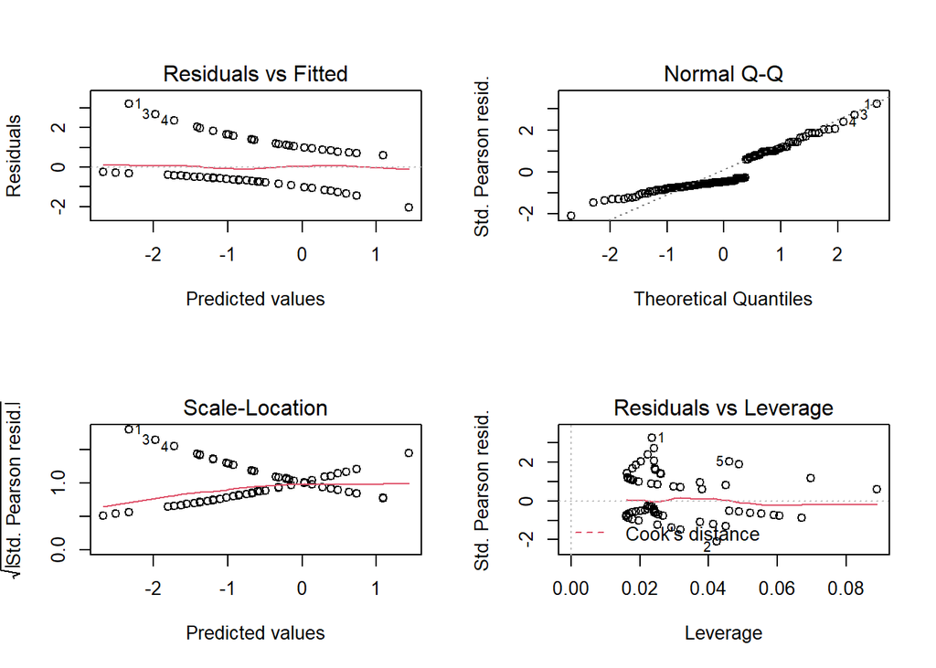

```r
par(mfrow=c(2,2))
plot(glm35)
```

```r
# Of interest is mainly the last plot.

# All seems reasonable:
# there is one observation (1) with a high value for Cook's diagnostic (the Pearson residual is quite high).
# There is also a value for which the hat value is quite large (46-the combination of LOC=LUMBAR and STEN as high as 70 is unusual)
# For some other observations Cook's diagnostic and the dffit are also a bit high

#
# another useful function is:
# influence.measures(glm35)
influence.measures(glm35)
```

```
## Influence measures of
##   glm(formula = DEF ~ LOC + STEN, family = binomial, data = fracture) :
##
##        dfb.1_ dfb.LOCthrcl dfb.LOCthrcc dfb.STEN   dffit cov.r   cook.d    hat
## 1    0.070121     0.073497      0.22196 -0.24969  0.3217 0.930 0.063419 0.0236
## 2    0.087871     0.014396      0.15644 -0.31290 -0.3609 0.986 0.048467 0.0423
## 3    0.059528     0.062395      0.20993 -0.21197  0.3034 0.946 0.045822 0.0242
## 4    0.060666     0.137768      0.10801 -0.21603  0.2759 0.956 0.032935 0.0224
## 5    0.372310    -0.273820     -0.20561 -0.10456  0.3723 0.992 0.049968 0.0461
## 6    0.366334    -0.284642     -0.22221 -0.07489  0.3675 1.002 0.044765 0.0489
## 7    0.366334    -0.284642     -0.22221 -0.07489  0.3675 1.002 0.044765 0.0489
## 8    0.366334    -0.284642     -0.22221 -0.07489  0.3675 1.002 0.044765 0.0489
## 9    0.036932     0.038710      0.17642 -0.13151  0.2660 0.970 0.026053 0.0241
## 10   0.050098     0.052510     -0.01679 -0.17839 -0.2843 1.025 0.020018 0.0451
## 11   0.050098     0.052510     -0.01679 -0.17839 -0.2843 1.025 0.020018 0.0451
## 12   0.050098     0.052510     -0.01679 -0.17839 -0.2843 1.025 0.020018 0.0451
## 13   0.045808     0.124196      0.08155 -0.16312  0.2402 0.968 0.020821 0.0202
## 14   0.040318     0.042259     -0.02951 -0.14357 -0.2557 1.027 0.015264 0.0413
## 15   0.017114     0.017938      0.14123 -0.06094  0.2393 0.987 0.017329 0.0244
## 16   0.052476    -0.020201      0.09342 -0.18686 -0.2554 1.004 0.017734 0.0319
## 17   0.037659     0.115854      0.06705 -0.13410  0.2219 0.974 0.016337 0.0190
## 18   0.013747     0.014409      0.13477 -0.04895  0.2355 0.990 0.016296 0.0246
## 19   0.283574    -0.297964     -0.27353  0.08478  0.3313 1.060 0.024885 0.0696
## 20   0.030995     0.032487     -0.04066 -0.11037 -0.2286 1.029 0.011563 0.0376
## 21  -0.234621     0.238738      0.21612 -0.05582 -0.2667 1.072 0.014013 0.0671
## 22  -0.234621     0.238738      0.21612 -0.05582 -0.2667 1.072 0.014013 0.0671
## 23   0.002161     0.002265      0.11136 -0.00769  0.2247 1.000 0.013437 0.0259
## 24   0.044878    -0.026389      0.07990 -0.15981 -0.2333 1.006 0.014030 0.0292
## 25   0.000552     0.000579      0.10796 -0.00197  0.2235 1.001 0.013111 0.0262
## 26   0.029239     0.106635      0.05206 -0.10412  0.2044 0.980 0.012804 0.0178
## 27  -0.210355     0.196462      0.17077 -0.01771 -0.2251 1.071 0.009422 0.0606
## 28  -0.028183    -0.029540      0.03698  0.10036  0.2079 1.036 0.008904 0.0376
## 29  -0.028183    -0.029540      0.03698  0.10036  0.2079 1.036 0.008904 0.0376
## 30  -0.028183    -0.029540      0.03698  0.10036  0.2079 1.036 0.008904 0.0376
## 31  -0.028183    -0.029540      0.03698  0.10036  0.2079 1.036 0.008904 0.0376
## 32   0.033706    -0.034706      0.06001 -0.12002 -0.2017 1.009 0.009740 0.0252
## 33   0.033706    -0.034706      0.06001 -0.12002 -0.2017 1.009 0.009740 0.0252
## 34  -0.203902     0.186387      0.16024 -0.00972 -0.2155 1.071 0.008531 0.0590
## 35  -0.203902     0.186387      0.16024 -0.00972 -0.2155 1.071 0.008531 0.0590
## 36  -0.035291    -0.036991      0.01182  0.12567  0.2003 1.052 0.007634 0.0451
```

[output cut: 228 more lines]

[output not shown]

### Question 10

Plot the area under the AUC curve for the model you estimated in question 5 (which we have called `glm35`) using the `ROC` function of the `Epi` package. Also compute Nagelkerke’s R2 measure. For this you can use the `PseudoR2` function in the `DescTools` package. The packages `Epi` and `DescTools` are already loaded.

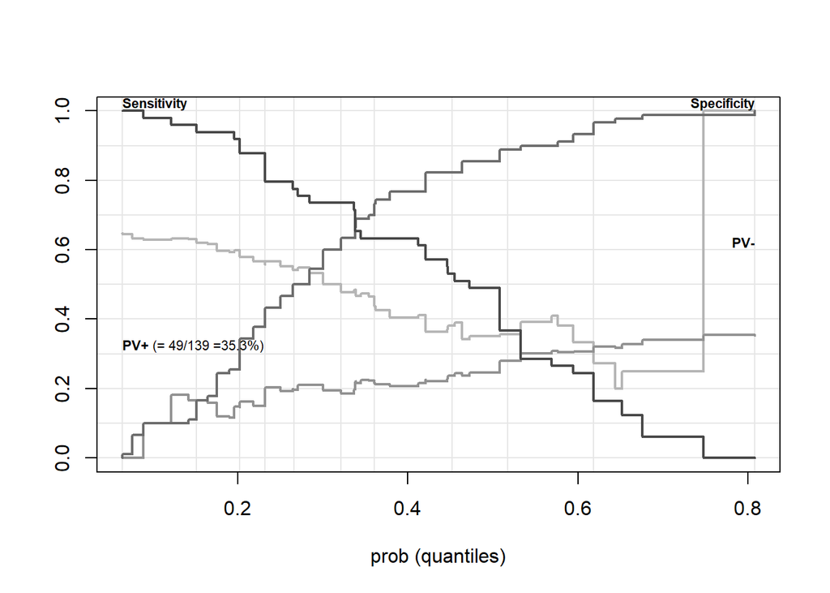

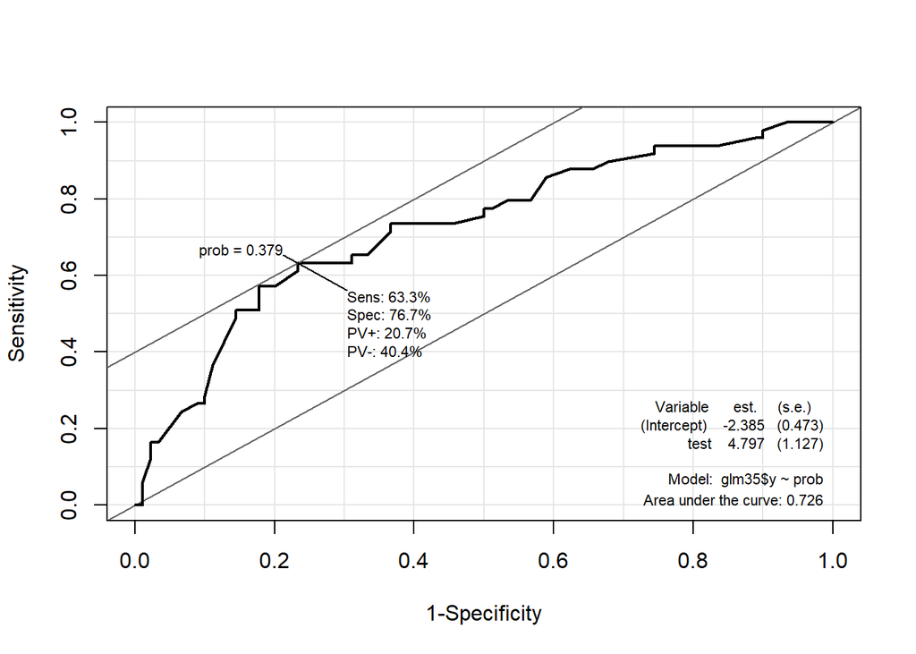

```r
prob <- predict(glm35, type='response')
ROC(test = prob, stat = glm35$y)
```

```r
PseudoR2(glm35, which='Nagelkerke')
```

```
## Nagelkerke
##  0.1888965
```